# Project Python Foundations: FoodHub Data Analysis

### **Question 7**: Which are the top 5 restaurants in terms of the number of orders received? [1 mark]

```python
df['restaurant_name'].value_counts().sort_values( ascending = False).head(5)
```

```
Shake Shack                  219
The Meatball Shop            132
Blue Ribbon Sushi            119
Blue Ribbon Fried Chicken     96
Parm                          68
Name: restaurant_name, dtype: int64
```

#### Observations: The top 5 restaurants in terms of orders are,

1. shake shack
2. the meatball shop
3. blue ribbon sushi
4. blue ribbon fried chicken
5. parm

### **Question 8**: Which is the most popular cuisine on weekends? [1 mark]

```python
df.groupby(['day_of_the_week'])['cuisine_type'].value_counts()
```

```
day_of_the_week  cuisine_type
Weekday          American          169
                 Japanese          135
                 Italian            91
                 Chinese            52
                 Indian             24
                 Mexican            24
                 Middle Eastern     17
                 Mediterranean      14
                 Southern            6
                 French              5
                 Thai                4
                 Vietnamese          3
                 Korean              2
                 Spanish             1
Weekend          American          415
                 Japanese          335
                 Italian           207
                 Chinese           163
                 Mexican            53
                 Indian             49
                 Mediterranean      32
                 Middle Eastern     32
                 Thai               15
                 French             13
                 Korean             11
                 Southern           11
                 Spanish            11
                 Vietnamese          4
Name: cuisine_type, dtype: int64
```

#### Observations: American food is the most popular type of cuisine on the weekend.

### **Question 9**: What percentage of the orders cost more than 20 dollars? [2 marks]

```python
100*(len(df[df['cost_of_the_order']>20])/len(df))
```

```
29.24130663856691
```

```python
len(df)
```

```
1898
```

#### Observations: 29.24 percent of the orders cost more than $20.

### **Question 10**: What is the mean order delivery time? [1 mark]

```python
df['delivery_time'].mean()
```

```
24.161749209694417
```

#### Observations: The mean for order delivery time is 24.16 minutes.

### **Question 11:** The company has decided to give 20% discount vouchers to the top 5 most frequent customers. Find the IDs of these customers and the number of orders they placed. [1 mark]

```python
df['customer_id'].value_counts().sort_values(ascending = False).head(5)
```

```
52832     13
47440     10
83287      9
250494     8
259341     7
Name: customer_id, dtype: int64
```

#### Observations: The most ordered by a customer is 13 (id-52832), second is 10 (id-47440), third is 9 (id-83287), forth is 8 (id-250494), and fifth is 7 (id 259341).

### **Question 12**: Perform a multivariate analysis to explore relationships between the important variables in the dataset. (It is a good idea to explore relations between numerical variables as well as relations between numerical and categorical variables) [10 marks]

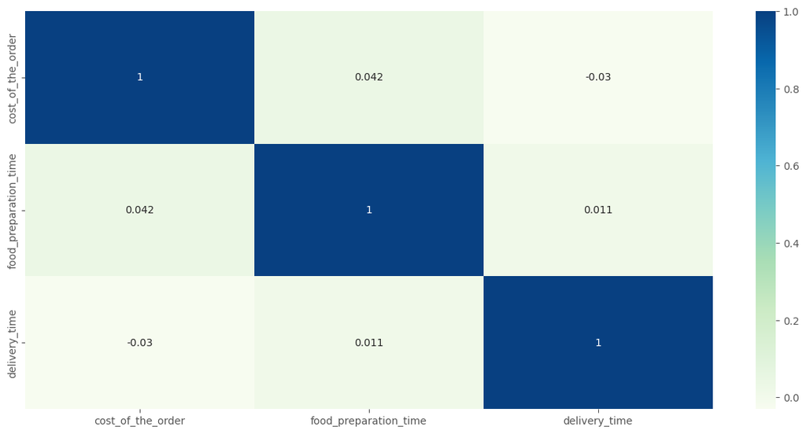

```python
plt.figure(figsize =(15,7))
sns.heatmap(df[['cost_of_the_order','food_preparation_time','delivery_time']].corr()
                , annot =True, cmap = "GnBu" )
```

Observation: Food preparation type and cost of the order have a more positive correlation between each other.

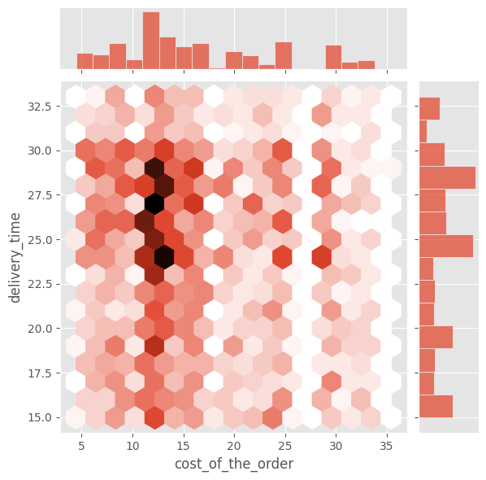

```python
sns.jointplot(data = df, x = 'cost_of_the_order', y = 'delivery_time', kind ='hex')
```

Observation: Delivery time for orders between the 10-15 dollar mark takes about 23-30 minutes to deliver.

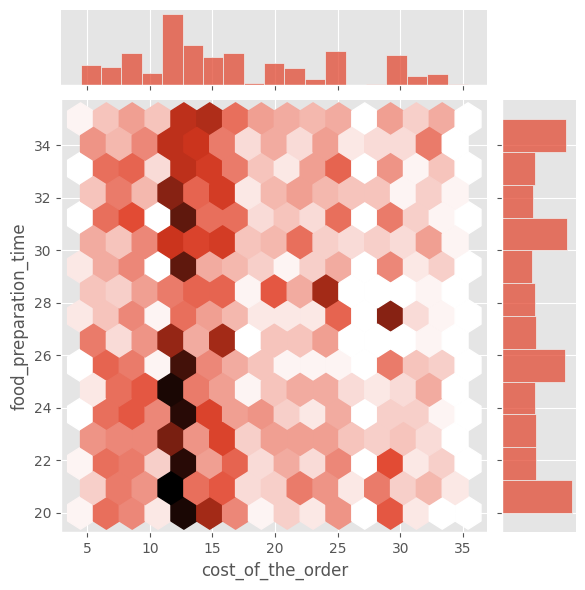

```python
sns.jointplot(data = df, x = 'cost_of_the_order', y = 'food_preparation_time', kind ='hex')
```

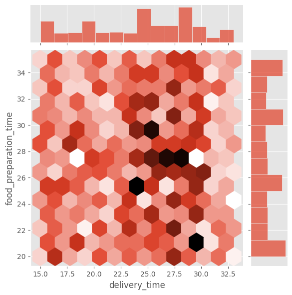

```python
sns.jointplot(data = df, x = 'delivery_time', y = 'food_preparation_time', kind ='hex')
```

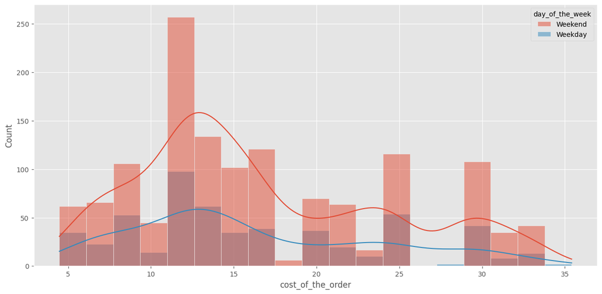

```python
plt.figure(figsize =(15,7))

sns.histplot(data =df, x ='cost_of_the_order', kde = True, hue = 'day_of_the_week')

plt.show()
```

Observation: Both on the weekend and weekday the price range from 10-15 dollars dominates the food delivery service.

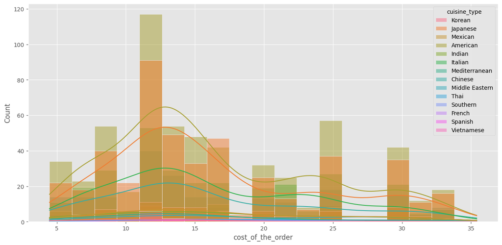

```python
plt.figure(figsize =(15,7))

sns.histplot(data =df, x ='cost_of_the_order', kde = True, hue = 'cuisine_type')

plt.show()
```

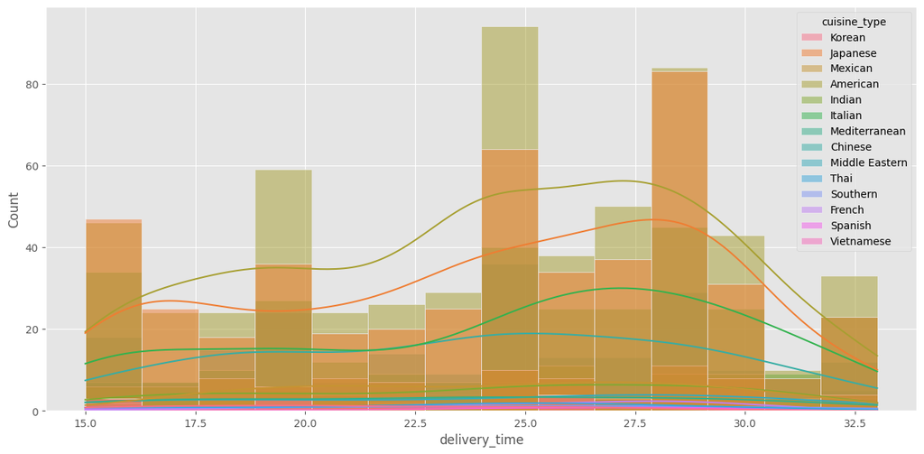

```python
plt.figure(figsize =(15,7))

sns.histplot(data =df, x ='delivery_time', kde = True, hue = 'cuisine_type')

plt.show()
```

Observations: Italian, Japanese, and American food have most of their orders in higher delivery times (22.5-30 minutes), reason could be because of the high demand for their food.

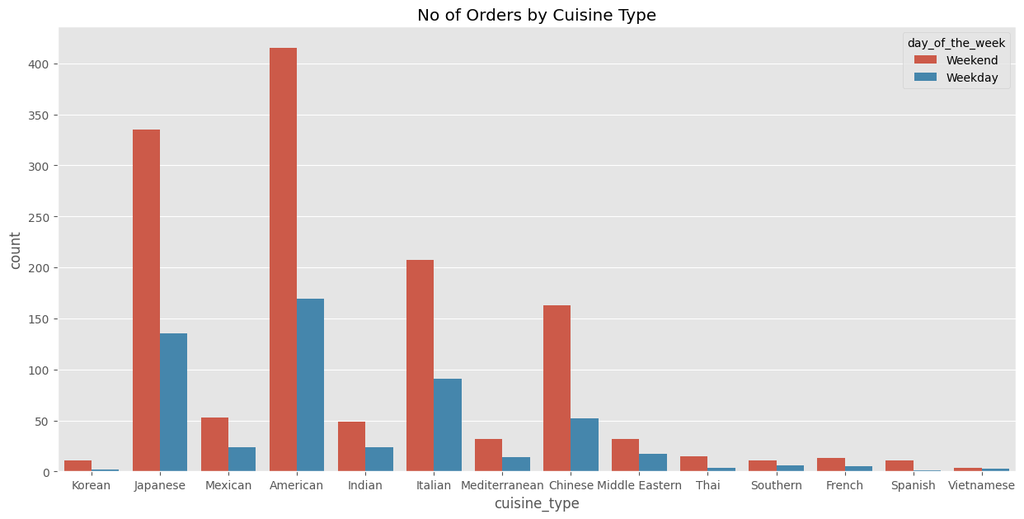

```python
plt.figure(figsize =(15,7))

sns.countplot(data =df, x ='cuisine_type', hue ='day_of_the_week')
ylabel = "No of orders"
plt.title("No of Orders by Cuisine Type")
plt.show()
```

Observations: Japanese, American, and Italian cuisine restaurants have most online orders during the weekend and weekday. The weekend have far more orders.

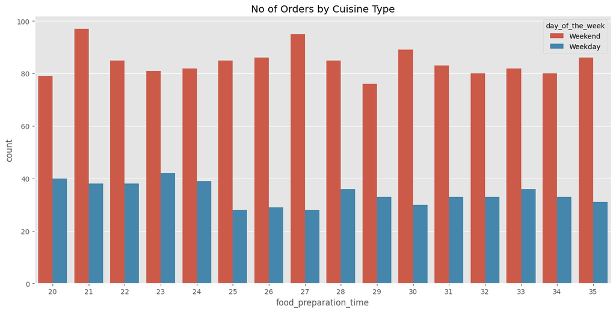

```python
plt.figure(figsize =(15,7))

sns.countplot(data =df, x ='food_preparation_time', hue ='day_of_the_week')
ylabel = "No of orders"
plt.title("No of Orders by Cuisine Type")
plt.show()
```

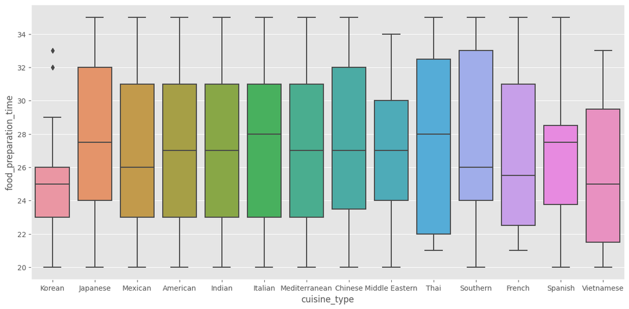

```python
plt.figure(figsize =(15,7))
sns.boxplot(data =df, y = 'food_preparation_time',x='cuisine_type')
```

### **Question 13:** The company wants to provide a promotional offer in the advertisement of the restaurants. The condition to get the offer is that the restaurants must have a rating count of more than 50 and the average rating should be greater than 4. Find the restaurants fulfilling the criteria to get the promotional offer. [3 marks]

```python
df['rating'].unique()
```

```
array(['Not given', '5', '3', '4'], dtype=object)
```

```python
df_nan = df.replace(to_replace = 'Not given', value = np.NaN)
```

```python
df_nan['rating'].unique()
```

```
array([nan, '5', '3', '4'], dtype=object)
```

```python
df_nan.head()
```

|  | order_id | customer_id | restaurant_name | cuisine_type | cost_of_the_order | day_of_the_week | rating | food_preparation_time | delivery_time |
| --- | --- | --- | --- | --- | --- | --- | --- | --- | --- |
| 0 | 1477147 | 337525 | Hangawi | Korean | 30.75 | Weekend | NaN | 25 | 20 |
| 1 | 1477685 | 358141 | Blue Ribbon Sushi Izakaya | Japanese | 12.08 | Weekend | NaN | 25 | 23 |
| 2 | 1477070 | 66393 | Cafe Habana | Mexican | 12.23 | Weekday | 5 | 23 | 28 |
| 3 | 1477334 | 106968 | Blue Ribbon Fried Chicken | American | 29.20 | Weekend | 3 | 25 | 15 |
| 4 | 1478249 | 76942 | Dirty Bird to Go | American | 11.59 | Weekday | 4 | 25 | 24 |

```python
df_nan['rating'] =df_nan['rating'].astype(dtype ='float', errors = 'ignore')
```

```python
ratings = df_nan.groupby('restaurant_name')['rating'].mean()
```

```python
ratings
```

```
restaurant_name
'wichcraft          5.000000
12 Chairs           4.500000
5 Napkin Burger     4.000000
67 Burger           5.000000
Alidoro                  NaN
                      ...
Zero Otto Nove      4.000000
brgr                3.000000
da Umberto          5.000000
ilili Restaurant    4.153846
indikitch           4.500000
Name: rating, Length: 178, dtype: float64
```

```python
ratings_count = df_nan.groupby('restaurant_name')['rating'].mean()
```

```python
combined_df = pd.merge(ratings,ratings_count, how ='inner', on = ratings.index)
```

```python
combined_df.rename(columns = {'key_0':'Restaurant Name', 'rating_x': 'Avg Ratings', 'rating_y':" Rating Counts"}, inplace = True)
```

```python
combined_df
```

|  | Restaurant Name | Avg Ratings | Rating Counts |
| --- | --- | --- | --- |
| 0 | 'wichcraft | 5.000000 | 5.000000 |
| 1 | 12 Chairs | 4.500000 | 4.500000 |
| 2 | 5 Napkin Burger | 4.000000 | 4.000000 |
| 3 | 67 Burger | 5.000000 | 5.000000 |
| 4 | Alidoro | NaN | NaN |
| ... | ... | ... | ... |
| 173 | Zero Otto Nove | 4.000000 | 4.000000 |
| 174 | brgr | 3.000000 | 3.000000 |
| 175 | da Umberto | 5.000000 | 5.000000 |
| 176 | ilili Restaurant | 4.153846 | 4.153846 |
| 177 | indikitch | 4.500000 | 4.500000 |

178 rows × 3 columns

```python
combined_df[(combined_df['Avg Ratings']>4) & (combined_df['Rating Counts']>50)]
```

[output not shown]

### **Question 14:** The company charges the restaurant 25% on the orders having cost greater than 20 dollars and 15% on the orders having cost greater than 5 dollars. Find the net revenue generated by the company across all orders. [3 marks]

```python
sum = 0

for i in df['cost_of_the_order']:
  if i > 20:
    sum = sum+ (i*0.25)
  elif (5 < i < 20):
    sum = sum+ (i*0.15)
  else:
    sum = sum+(i*0)
print( "Total Revenue Generate is", sum)
```

```
Total Revenue Generate is 6166.302999999994
```

Observations: The total revenue generated by the company across all orders is $6166.30

### **Question 15:** The company wants to analyze the total time required to deliver the food. What percentage of orders take more than 60 minutes to get delivered from the time the order is placed? (The food has to be prepared and then delivered.) [2 marks]

```python
df['total_time'] =df['food_preparation_time']+df['delivery_time']
```

```python
100* len(df[df['total_time']>60])/len(df)
```

```
10.53740779768177
```

#### Observations: 10% of the orders take more than 60 minutes to get delivered.

### **Question 16:** The company wants to analyze the delivery time of the orders on weekdays and weekends. How does the mean delivery time vary during weekdays and weekends? [2 marks]

```python
df.groupby(['day_of_the_week'])['delivery_time'].mean()
```

```
day_of_the_week
Weekday    28.340037
Weekend    22.470022
Name: delivery_time, dtype: float64
```

### Recommendations: To get more reviews on the customers who leave none, make these adjustments.

1. Set app to make it mandatory to leave a review (such as Great learning platoform after live sessions).
2. Make it easier for delivery people to find addresses, restaurants, routes, etc (time matters).
3. Delivery people need to be held more accountable for customers orders taking too long.
4. Offer in app prizes for customers who use the app more and leave reviews.
5. Hire more delivery people for the busy weekend.
6. Create feature in app to offer recommendations to places with less wait times.